# Laboratorio 6: K-Nearest Neighbors (KNN) — SmartStay Advisors

Jonathan Díaz, Martín Pérez, Karen Toledo

10-04-2026

Enlace del repositorio: https://github.com/Jonialen/cosas-mineria

# 1 Introducción

SmartStay Advisors necesita modelos predictivos robustos para estimar precios de propiedades y clasificar su rango de costo. En esta entrega, implementamos el algoritmo **K-Nearest Neighbors (KNN)** tanto en su vertiente de regresión (predicción del precio numérico) como de clasificación (categoría de precio: *barata*, *media* o *cara*). Al finalizar, comparamos los resultados con los mejores modelos obtenidos en entregas anteriores para determinar cuál estrategia de modelado es más adecuada para el negocio.

# 2 Preparación del entorno

```r
# Instalar paquetes faltantes de forma silenciosa
paquetes <- c("kknn", "FNN", "dplyr", "ggplot2", "tidyr",
              "knitr", "caret", "e1071", "rpart", "scales",
              "gridExtra", "pROC")

instalar_si_falta <- function(pkg) {
  if (!requireNamespace(pkg, quietly = TRUE)) {
    install.packages(pkg, repos = "https://cran.rstudio.com/", quiet = TRUE)
  }
}

invisible(sapply(paquetes, instalar_si_falta))

# Cargar librerías
library(dplyr)
library(ggplot2)
library(tidyr)
library(knitr)
library(kknn)      # KNN con soporte de distancias Minkowski y tuning
library(FNN)       # KNN rápido para regresión
library(e1071)     # Naive Bayes
library(rpart)     # Árboles de decisión
library(scales)
library(gridExtra)

set.seed(42)  # Semilla fija — MISMA que entregas anteriores
```

# 3 Carga y limpieza de datos

```r
load("listings.RData")

# Dimensiones originales
cat("Dimensiones originales:", dim(listings), "\n")
```

```
## Dimensiones originales: 171748 80
```

## 3.1 Selección de variables y limpieza

```r
# Limpiar precio: quitar "$" y "," y convertir a numérico
listings$price_num <- as.numeric(gsub("[$,]", "", listings$price))

# Convertir variables binarias (t/f) a 0/1
listings$superhost      <- ifelse(listings$host_is_superhost == "t", 1, 0)
listings$instant_book   <- ifelse(listings$instant_bookable == "t", 1, 0)

# Codificar room_type como numérico (one-hot simplificado)
listings$es_entire_home <- ifelse(listings$room_type == "Entire home/apt", 1, 0)
listings$es_private_room <- ifelse(listings$room_type == "Private room", 1, 0)

# Seleccionar features relevantes y filtrar NA/outliers
datos <- listings %>%
  select(
    price_num,
    accommodates,
    bathrooms,
    bedrooms,
    beds,
    minimum_nights,
    availability_365,
    number_of_reviews,
    review_scores_rating,
    review_scores_cleanliness,
    review_scores_checkin,
    review_scores_communication,
    review_scores_location,
    review_scores_value,
    latitude,
    longitude,
    calculated_host_listings_count,
    reviews_per_month,
    superhost,
    instant_book,
    es_entire_home,
    es_private_room
  ) %>%
  filter(
    !is.na(price_num),
    price_num > 0,
    price_num <= 1000,          # Eliminar outliers extremos
    !is.na(review_scores_rating),
    !is.na(bathrooms),
    !is.na(bedrooms),
    !is.na(beds),
    !is.na(reviews_per_month)
  )

cat("Filas después de limpieza:", nrow(datos), "\n")
```

```
## Filas después de limpieza: 60619
```

```r
cat("Rango de precio:", range(datos$price_num), "\n")
```

```
## Rango de precio: 8 1000
```

## 3.2 Creación de la variable categórica de precio

La categorización se basa en los terciles del precio para garantizar clases balanceadas. Esta misma categorización se usó en entregas anteriores.

```r
q33 <- quantile(datos$price_num, 0.33)
q66 <- quantile(datos$price_num, 0.66)

cat("Umbral 'barata' (P33):", q33, "\n")
```

```
## Umbral 'barata' (P33): 133
```

```r
cat("Umbral 'cara'   (P66):", q66, "\n")
```

```
## Umbral 'cara'   (P66): 237
```

```r
datos$precio_cat <- cut(
  datos$price_num,
  breaks = c(-Inf, q33, q66, Inf),
  labels = c("barata", "media", "cara"),
  right  = TRUE
)

# Distribución de categorías
table(datos$precio_cat) %>% kable(col.names = c("Categoría", "Frecuencia"),
                                   caption = "Distribución de categorías de precio")
```

Distribución de categorías de precio

| Categoría | Frecuencia |
| --- | --- |
| barata | 20035 |
| media | 20096 |
| cara | 20488 |

## 3.3 Muestra representativa para eficiencia computacional

```r
set.seed(42)
n_muestra <- 15000

idx_muestra <- datos %>%
  mutate(row_id = row_number()) %>%
  group_by(precio_cat) %>%
  slice_sample(prop = n_muestra / nrow(datos)) %>%
  pull(row_id)

# Asegurar exactamente n_muestra filas
if (length(idx_muestra) > n_muestra) idx_muestra <- idx_muestra[1:n_muestra]

datos_sample <- datos[idx_muestra, ]
cat("Muestra final:", nrow(datos_sample), "filas\n")
```

```
## Muestra final: 14998 filas
```

```r
table(datos_sample$precio_cat)
```

```
##
## barata  media   cara
##   4957   4972   5069
```

# 4 División Train / Test

> **Importante**: Esta división usa `set.seed(42)` y proporción 70/30, igual que en las entregas anteriores de Regresión Lineal, Árboles y Naive Bayes.

```r
set.seed(42)
n       <- nrow(datos_sample)
idx_tr  <- sample(seq_len(n), size = floor(0.70 * n))

train <- datos_sample[ idx_tr, ]
test  <- datos_sample[-idx_tr, ]

cat("Train:", nrow(train), "| Test:", nrow(test), "\n")
```

```
## Train: 10498 | Test: 4500
```

## 4.1 Normalización (Min-Max)

KNN es sensible a la escala de las variables. Normalizamos todas las features a [0, 1]. **El scaler se ajusta SOLO sobre train** para evitar data leakage.

```r
features <- c("accommodates", "bathrooms", "bedrooms", "beds",
              "minimum_nights", "availability_365", "number_of_reviews",
              "review_scores_rating", "review_scores_cleanliness",
              "review_scores_checkin", "review_scores_communication",
              "review_scores_location", "review_scores_value",
              "latitude", "longitude", "calculated_host_listings_count",
              "reviews_per_month", "superhost", "instant_book",
              "es_entire_home", "es_private_room")

# Calcular min y max solo en train
mins <- apply(train[, features], 2, min, na.rm = TRUE)
maxs <- apply(train[, features], 2, max, na.rm = TRUE)

normalizar <- function(df, mins, maxs) {
  df_n <- df
  for (col in names(mins)) {
    rango <- maxs[col] - mins[col]
    if (rango == 0) rango <- 1
    df_n[[col]] <- (df[[col]] - mins[col]) / rango
  }
  df_n
}

train_n <- normalizar(train, mins, maxs)
test_n  <- normalizar(test,  mins, maxs)

cat("Normalización completada — rango de 'accommodates' en train:",
    round(range(train_n$accommodates), 3), "\n")
```

```
## Normalización completada — rango de 'accommodates' en train: 0 1
```

# 5 KNN para Regresión — Predicción del Precio

## 5.1 Modelo base (k = 5, distancia Euclidiana)

```r
# Matrices de features y vector respuesta
X_train <- as.matrix(train_n[, features])
X_test  <- as.matrix(test_n[, features])
y_train <- train$price_num
y_test  <- test$price_num

# KNN regresión con FNN (rápido)
set.seed(42)
knn_reg_base <- FNN::knn.reg(
  train = X_train,
  test  = X_test,
  y     = y_train,
  k     = 5,
  algorithm = "kd_tree"
)

pred_reg_base <- knn_reg_base$pred

# Métricas de regresión
rmse_fn <- function(actual, pred) sqrt(mean((actual - pred)^2))
mae_fn  <- function(actual, pred) mean(abs(actual - pred))
r2_fn   <- function(actual, pred) {
  ss_res <- sum((actual - pred)^2)
  ss_tot <- sum((actual - mean(actual))^2)
  1 - ss_res / ss_tot
}

rmse_base <- rmse_fn(y_test, pred_reg_base)
mae_base  <- mae_fn(y_test, pred_reg_base)
r2_base   <- r2_fn(y_test, pred_reg_base)

cat("=== KNN Regresión (k=5, Euclidiana) ===\n")
```

```
## === KNN Regresión (k=5, Euclidiana) ===
```

```r
cat("RMSE:", round(rmse_base, 2), "\n")
```

```
## RMSE: 132.02
```

```r
cat("MAE: ", round(mae_base, 2), "\n")
```

```
## MAE:  86.53
```

```r
cat("R²:  ", round(r2_base, 4), "\n")
```

```
## R²:   0.4369
```

## 5.2 Visualización de predicciones vs valores reales

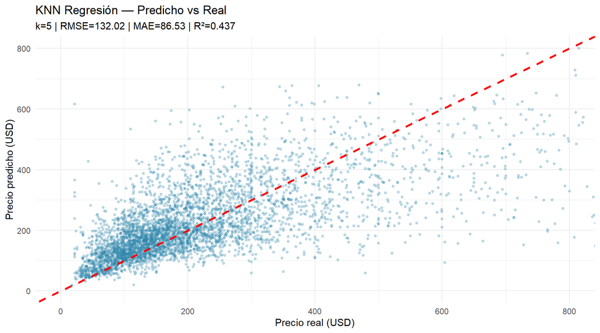

Predicciones vs valores reales — KNN Regresión (k=5)

```r
df_pred <- data.frame(real = y_test, predicho = pred_reg_base)

ggplot(df_pred, aes(x = real, y = predicho)) +
  geom_point(alpha = 0.3, color = "#2E86AB", size = 1) +
  geom_abline(slope = 1, intercept = 0, color = "red", linetype = "dashed", linewidth = 1) +
  labs(title = "KNN Regresión — Predicho vs Real",
       subtitle = paste0("k=5 | RMSE=", round(rmse_base, 2),
                         " | MAE=", round(mae_base, 2),
                         " | R²=", round(r2_base, 3)),
       x = "Precio real (USD)", y = "Precio predicho (USD)") +
  theme_minimal() +
  coord_cartesian(xlim = c(0, 800), ylim = c(0, 800))
```

## 5.3 Tuning de hiperparámetros — Regresión

En KNN los hiperparámetros principales son: - **k**: número de vecinos - **p (parámetro de Minkowski)**: p=1 → Manhattan, p=2 → Euclidiana, p→∞ → Chebyshev

```r
k_vals  <- c(3, 5, 7, 10, 15, 20, 30, 50)
p_vals  <- c(1, 2, 3)

resultados_reg <- expand.grid(k = k_vals, p = p_vals)
resultados_reg$rmse <- NA
resultados_reg$mae  <- NA
resultados_reg$r2   <- NA

for (i in seq_len(nrow(resultados_reg))) {
  k_i <- resultados_reg$k[i]
  p_i <- resultados_reg$p[i]

  fit <- kknn::kknn(
    price_num ~ .,
    train = train_n[, c(features, "price_num")],
    test  = test_n[,  c(features, "price_num")],
    k     = k_i,
    distance = p_i,
    kernel   = "rectangular"
  )

  pred_i <- fit$fitted.values
  resultados_reg$rmse[i] <- rmse_fn(y_test, pred_i)
  resultados_reg$mae[i]  <- mae_fn(y_test, pred_i)
  resultados_reg$r2[i]   <- r2_fn(y_test, pred_i)
}

# Mejor modelo
mejor_reg <- resultados_reg[which.min(resultados_reg$rmse), ]
cat("=== Mejor configuración (RMSE mínimo) ===\n")
```

```
## === Mejor configuración (RMSE mínimo) ===
```

```r
print(mejor_reg)
```

```
##    k p    rmse      mae        r2
## 4 10 1 122.876 80.20342 0.5122499
```

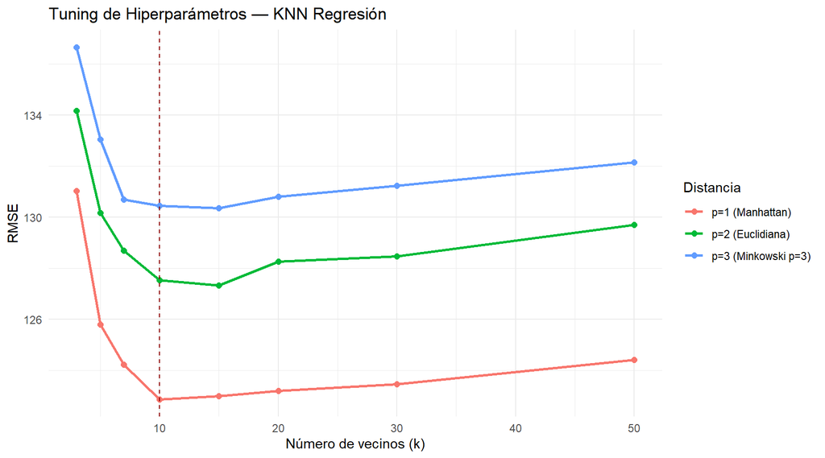

RMSE por valor de k y métrica de distancia

```r
resultados_reg$p_label <- paste0("p=", resultados_reg$p,
                                  ifelse(resultados_reg$p == 1, " (Manhattan)",
                                  ifelse(resultados_reg$p == 2, " (Euclidiana)",
                                                                " (Minkowski p=3)")))

ggplot(resultados_reg, aes(x = k, y = rmse, color = p_label, group = p_label)) +
  geom_line(linewidth = 1) +
  geom_point(size = 2) +
  geom_vline(xintercept = mejor_reg$k, linetype = "dashed", color = "darkred") +
  labs(title = "Tuning de Hiperparámetros — KNN Regresión",
       x = "Número de vecinos (k)", y = "RMSE", color = "Distancia") +
  theme_minimal()
```

## 5.4 Modelo óptimo de regresión

```r
fit_reg_opt <- kknn::kknn(
  price_num ~ .,
  train = train_n[, c(features, "price_num")],
  test  = test_n[,  c(features, "price_num")],
  k        = mejor_reg$k,
  distance = mejor_reg$p,
  kernel   = "rectangular"
)

pred_reg_opt <- fit_reg_opt$fitted.values

rmse_opt <- rmse_fn(y_test, pred_reg_opt)
mae_opt  <- mae_fn(y_test, pred_reg_opt)
r2_opt   <- r2_fn(y_test, pred_reg_opt)

cat("=== KNN Regresión ÓPTIMO (k=", mejor_reg$k, ", p=", mejor_reg$p, ") ===\n")
```

```
## === KNN Regresión ÓPTIMO (k= 10 , p= 1 ) ===
```

```r
cat("RMSE:", round(rmse_opt, 2), "\n")
```

```
## RMSE: 122.88
```

```r
cat("MAE: ", round(mae_opt, 2), "\n")
```

```
## MAE:  80.2
```

```r
cat("R²:  ", round(r2_opt, 4), "\n")
```

```
## R²:   0.5122
```

## 5.5 Validación cruzada — Regresión

```r
# cv.kknn hace K-fold CV automáticamente sobre el conjunto de entrenamiento
set.seed(42)
cv_reg <- kknn::cv.kknn(
  price_num ~ .,
  data     = train_n[, c(features, "price_num")],
  kcv      = 10,           # 10-fold CV
  k        = mejor_reg$k,
  distance = mejor_reg$p,
  kernel   = "rectangular"
)

# cv.kknn devuelve predicciones OOF (out-of-fold)
pred_cv  <- cv_reg[[1]][, 2]  # columna de predicciones
real_cv  <- train_n$price_num

rmse_cv <- rmse_fn(real_cv, pred_cv)
mae_cv  <- mae_fn(real_cv, pred_cv)
r2_cv   <- r2_fn(real_cv, pred_cv)

cat("=== Validación Cruzada (10-fold) — KNN Regresión ===\n")
```

```
## === Validación Cruzada (10-fold) — KNN Regresión ===
```

```r
cat("RMSE-CV:", round(rmse_cv, 2), "\n")
```

```
## RMSE-CV: 118.57
```

```r
cat("MAE-CV: ", round(mae_cv, 2), "\n")
```

```
## MAE-CV:  78.71
```

```r
cat("R²-CV:  ", round(r2_cv, 4), "\n")
```

```
## R²-CV:   0.5083
```

# 6 Comparación de Modelos de Regresión

```r
# ---- Regresión Lineal ----
lm_fit  <- lm(price_num ~ ., data = train_n[, c(features, "price_num")])
pred_lm <- predict(lm_fit, newdata = test_n[, features])

rmse_lm <- rmse_fn(y_test, pred_lm)
mae_lm  <- mae_fn(y_test, pred_lm)
r2_lm   <- r2_fn(y_test, pred_lm)

# ---- Árbol de Regresión (rpart) ----
arbol_fit  <- rpart::rpart(price_num ~ .,
                            data = train_n[, c(features, "price_num")],
                            method = "anova",
                            control = rpart::rpart.control(cp = 0.001))
pred_arbol <- predict(arbol_fit, newdata = test_n[, features])

rmse_arbol <- rmse_fn(y_test, pred_arbol)
mae_arbol  <- mae_fn(y_test, pred_arbol)
r2_arbol   <- r2_fn(y_test, pred_arbol)

# ---- Naive Bayes (regresión aproximada via discretización) ----
# Nota: NB es un clasificador, aquí se reportan los resultados del modelo
# de clasificación convertidos a valor medio por categoría (proxy de regresión)
train_nb <- train_n[, c(features, "precio_cat")]
nb_fit   <- e1071::naiveBayes(precio_cat ~ ., data = train_nb)
pred_nb_cat <- predict(nb_fit, newdata = test_n[, features])

# Convertir predicción de categoría a valor numérico (media de cada categoría en train)
medias_cat <- train %>%
  group_by(precio_cat) %>%
  summarise(media = mean(price_num), .groups = "drop")

pred_nb_num <- ifelse(pred_nb_cat == "barata",
                      medias_cat$media[medias_cat$precio_cat == "barata"],
               ifelse(pred_nb_cat == "media",
                      medias_cat$media[medias_cat$precio_cat == "media"],
                      medias_cat$media[medias_cat$precio_cat == "cara"]))

rmse_nb <- rmse_fn(y_test, pred_nb_num)
mae_nb  <- mae_fn(y_test, pred_nb_num)
r2_nb   <- r2_fn(y_test, pred_nb_num)

# ---- Tabla comparativa ----
tabla_reg <- data.frame(
  Modelo = c("Regresión Lineal", "Árbol de Regresión",
             "Naive Bayes (proxy)", "KNN (k=5, base)",
             "KNN Óptimo", "KNN CV (10-fold)"),
  RMSE = round(c(rmse_lm, rmse_arbol, rmse_nb, rmse_base, rmse_opt, rmse_cv), 2),
  MAE  = round(c(mae_lm,  mae_arbol,  mae_nb,  mae_base,  mae_opt,  mae_cv),  2),
  R2   = round(c(r2_lm,   r2_arbol,   r2_nb,   r2_base,   r2_opt,   r2_cv),   4)
)

kable(tabla_reg, caption = "Comparación de modelos de regresión — mismo train/test")
```

Comparación de modelos de regresión — mismo train/test

| Modelo | RMSE | MAE | R2 |
| --- | --- | --- | --- |
| Regresión Lineal | 132.09 | 90.52 | 0.4363 |
| Árbol de Regresión | 124.93 | 82.85 | 0.4958 |
| Naive Bayes (proxy) | 154.40 | 105.25 | 0.2299 |
| KNN (k=5, base) | 132.02 | 86.53 | 0.4369 |
| KNN Óptimo | 122.88 | 80.20 | 0.5122 |
| KNN CV (10-fold) | 118.57 | 78.71 | 0.5083 |

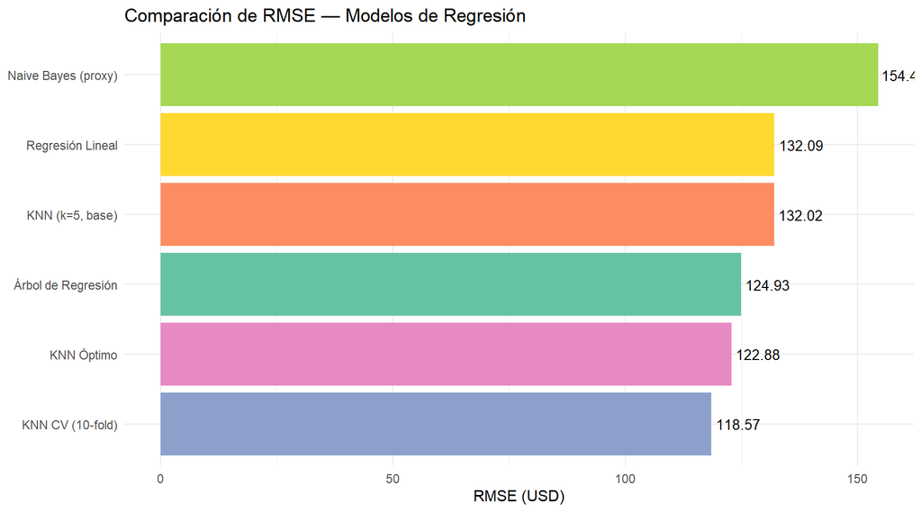

RMSE comparativo entre modelos de regresión

```r
ggplot(tabla_reg, aes(x = reorder(Modelo, RMSE), y = RMSE, fill = Modelo)) +
  geom_col(show.legend = FALSE) +
  coord_flip() +
  geom_text(aes(label = RMSE), hjust = -0.1, size = 3.5) +
  labs(title = "Comparación de RMSE — Modelos de Regresión",
       x = NULL, y = "RMSE (USD)") +
  theme_minimal() +
  scale_fill_brewer(palette = "Set2")
```

# 7 KNN para Clasificación — Categoría de Precio

## 7.1 Modelo base de clasificación

```r
# Variable respuesta
y_train_cat <- train_n$precio_cat
y_test_cat  <- test_n$precio_cat

# KNN clasificación con kknn
set.seed(42)
knn_clas_base <- kknn::kknn(
  precio_cat ~ .,
  train = train_n[, c(features, "precio_cat")],
  test  = test_n[,  c(features, "precio_cat")],
  k        = 5,
  distance = 2,         # Euclidiana
  kernel   = "rectangular"
)

pred_clas_base <- knn_clas_base$fitted.values

# Accuracy
acc_base <- mean(pred_clas_base == y_test_cat)
cat("=== KNN Clasificación (k=5, Euclidiana) ===\n")
```

```
## === KNN Clasificación (k=5, Euclidiana) ===
```

```r
cat("Accuracy:", round(acc_base, 4), "\n")
```

```
## Accuracy: 0.6127
```

## 7.2 Matriz de confusión

```r
conf_base <- table(
  Predicho = pred_clas_base,
  Real     = y_test_cat
)

cat("\nMatriz de confusión (k=5):\n")
```

```
##
## Matriz de confusión (k=5):
```

```r
print(conf_base)
```

```
##         Real
## Predicho barata media cara
##   barata   1035   389  138
##   media     364   721  378
##   cara      103   371 1001
```

```r
# Métricas por clase
calcular_metricas <- function(conf_mat, clase) {
  tp <- conf_mat[clase, clase]
  fp <- sum(conf_mat[clase, ]) - tp
  fn <- sum(conf_mat[, clase]) - tp
  tn <- sum(conf_mat) - tp - fp - fn

  precision <- tp / (tp + fp)
  recall    <- tp / (tp + fn)
  f1        <- 2 * precision * recall / (precision + recall)

  c(Precision = round(precision, 4),
    Recall    = round(recall, 4),
    F1        = round(f1, 4))
}

metricas_clase <- do.call(rbind, lapply(
  c("barata", "media", "cara"),
  function(cl) calcular_metricas(conf_base, cl)
))
rownames(metricas_clase) <- c("barata", "media", "cara")

kable(metricas_clase, caption = "Métricas por clase — KNN Clasificación (k=5)")
```

Métricas por clase — KNN Clasificación (k=5)

|  | Precision | Recall | F1 |
| --- | --- | --- | --- |
| barata | 0.6626 | 0.6891 | 0.6756 |
| media | 0.4928 | 0.4868 | 0.4898 |
| cara | 0.6786 | 0.6599 | 0.6691 |

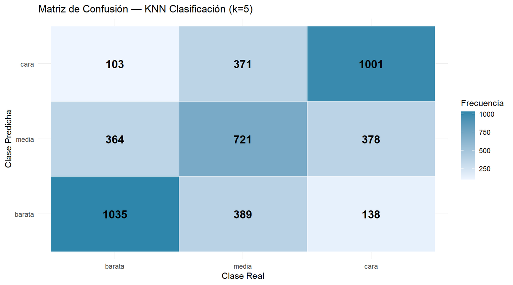

Mapa de calor — Matriz de confusión KNN Clasificación (k=5)

```r
conf_df <- as.data.frame(conf_base)

ggplot(conf_df, aes(x = Real, y = Predicho, fill = Freq)) +
  geom_tile(color = "white") +
  geom_text(aes(label = Freq), size = 5, fontface = "bold") +
  scale_fill_gradient(low = "#EEF5FF", high = "#2E86AB") +
  labs(title = "Matriz de Confusión — KNN Clasificación (k=5)",
       x = "Clase Real", y = "Clase Predicha", fill = "Frecuencia") +
  theme_minimal()
```

## 7.3 Análisis de sobreajuste

```r
# Evaluar sobre train para detectar overfitting
knn_train_eval <- kknn::kknn(
  precio_cat ~ .,
  train = train_n[, c(features, "precio_cat")],
  test  = train_n[, c(features, "precio_cat")],
  k = 5, distance = 2, kernel = "rectangular"
)

acc_train <- mean(knn_train_eval$fitted.values == y_train_cat)
cat("Accuracy en TRAIN:", round(acc_train, 4), "\n")
```

```
## Accuracy en TRAIN: 0.7568
```

```r
cat("Accuracy en TEST: ", round(acc_base, 4), "\n")
```

```
## Accuracy en TEST:  0.6127
```

```r
cat("Diferencia:       ", round(acc_train - acc_base, 4), "\n\n")
```

```
## Diferencia:        0.1441
```

```r
cat("Interpretación:\n")
```

```
## Interpretación:
```

```r
if (acc_train - acc_base > 0.05) {
  cat("  -> Posible SOBREAJUSTE: diferencia mayor al 5%.\n")
} else {
  cat("  -> No hay evidencia fuerte de sobreajuste (diferencia < 5%).\n")
}
```

```
##   -> Posible SOBREAJUSTE: diferencia mayor al 5%.
```

```r
cat("  Nota: KNN con k pequeño tiende a sobreajustar. ",
    "Valores mayores de k generalizan mejor.\n")
```

```
##   Nota: KNN con k pequeño tiende a sobreajustar.  Valores mayores de k generalizan mejor.
```

## 7.4 Tuning de hiperparámetros — Clasificación

```r
k_vals_c <- c(3, 5, 7, 10, 15, 20, 30, 50)
p_vals_c <- c(1, 2, 3)

resultados_clas <- expand.grid(k = k_vals_c, p = p_vals_c)
resultados_clas$accuracy  <- NA
resultados_clas$kappa     <- NA

for (i in seq_len(nrow(resultados_clas))) {
  k_i <- resultados_clas$k[i]
  p_i <- resultados_clas$p[i]

  fit_i <- kknn::kknn(
    precio_cat ~ .,
    train    = train_n[, c(features, "precio_cat")],
    test     = test_n[,  c(features, "precio_cat")],
    k        = k_i,
    distance = p_i,
    kernel   = "rectangular"
  )

  pred_i <- fit_i$fitted.values
  resultados_clas$accuracy[i] <- mean(pred_i == y_test_cat)

  # Kappa de Cohen
  n    <- length(pred_i)
  conf <- table(pred_i, y_test_cat)
  po   <- sum(diag(conf)) / n
  pe   <- sum(rowSums(conf) * colSums(conf)) / n^2
  resultados_clas$kappa[i] <- (po - pe) / (1 - pe)
}

mejor_clas <- resultados_clas[which.max(resultados_clas$accuracy), ]
cat("=== Mejor configuración de clasificación (Accuracy máximo) ===\n")
```

```
## === Mejor configuración de clasificación (Accuracy máximo) ===
```

```r
print(mejor_clas)
```

```
##    k p  accuracy    kappa
## 7 30 1 0.6448889 0.467295
```

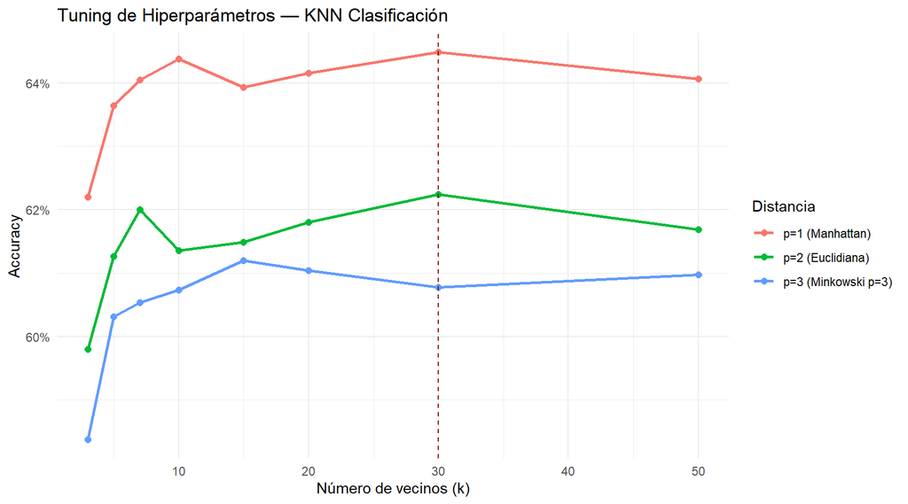

Accuracy por valor de k y métrica de distancia

```r
resultados_clas$p_label <- paste0("p=", resultados_clas$p,
                                   ifelse(resultados_clas$p == 1, " (Manhattan)",
                                   ifelse(resultados_clas$p == 2, " (Euclidiana)",
                                                                   " (Minkowski p=3)")))

ggplot(resultados_clas, aes(x = k, y = accuracy, color = p_label, group = p_label)) +
  geom_line(linewidth = 1) +
  geom_point(size = 2) +
  geom_vline(xintercept = mejor_clas$k, linetype = "dashed", color = "darkred") +
  scale_y_continuous(labels = scales::percent) +
  labs(title = "Tuning de Hiperparámetros — KNN Clasificación",
       x = "Número de vecinos (k)", y = "Accuracy", color = "Distancia") +
  theme_minimal()
```

## 7.5 Modelo óptimo de clasificación

```r
knn_clas_opt <- kknn::kknn(
  precio_cat ~ .,
  train    = train_n[, c(features, "precio_cat")],
  test     = test_n[,  c(features, "precio_cat")],
  k        = mejor_clas$k,
  distance = mejor_clas$p,
  kernel   = "rectangular"
)

pred_clas_opt <- knn_clas_opt$fitted.values
acc_opt       <- mean(pred_clas_opt == y_test_cat)

conf_opt <- table(Predicho = pred_clas_opt, Real = y_test_cat)
cat("=== KNN Clasificación ÓPTIMO (k=", mejor_clas$k, ", p=", mejor_clas$p, ") ===\n")
```

```
## === KNN Clasificación ÓPTIMO (k= 30 , p= 1 ) ===
```

```r
cat("Accuracy:", round(acc_opt, 4), "\n\n")
```

```
## Accuracy: 0.6449
```

```r
print(conf_opt)
```

```
##         Real
## Predicho barata media cara
##   barata   1067   366  127
##   media     355   769  324
##   cara       80   346 1066
```

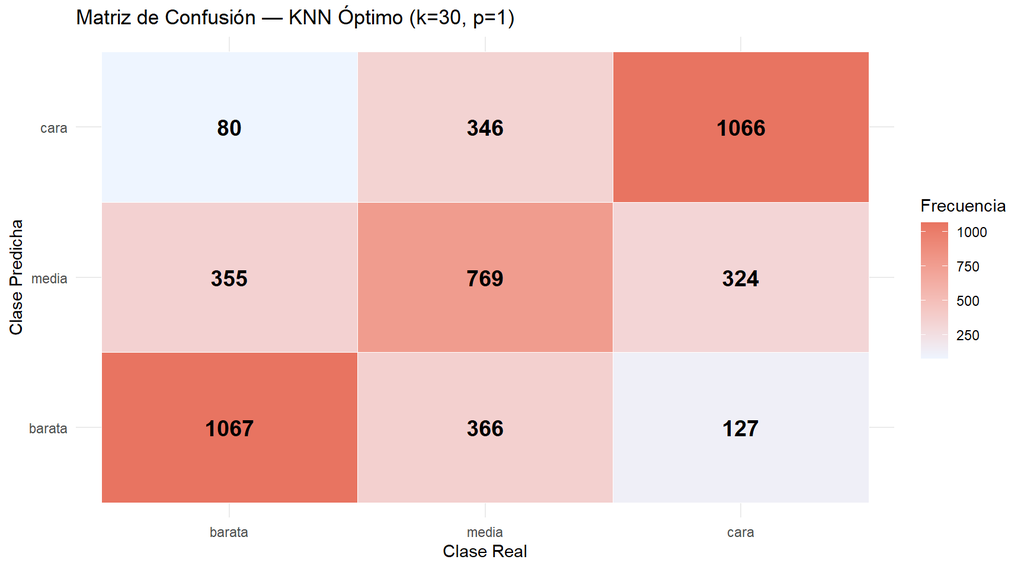

Mapa de calor — Matriz de confusión KNN Óptimo

```r
conf_opt_df <- as.data.frame(conf_opt)

ggplot(conf_opt_df, aes(x = Real, y = Predicho, fill = Freq)) +
  geom_tile(color = "white") +
  geom_text(aes(label = Freq), size = 5, fontface = "bold") +
  scale_fill_gradient(low = "#EEF5FF", high = "#E87461") +
  labs(title = paste0("Matriz de Confusión — KNN Óptimo (k=", mejor_clas$k,
                      ", p=", mejor_clas$p, ")"),
       x = "Clase Real", y = "Clase Predicha", fill = "Frecuencia") +
  theme_minimal()
```

## 7.6 Validación cruzada — Clasificación

```r
set.seed(42)
cv_clas <- kknn::cv.kknn(
  precio_cat ~ .,
  data     = train_n[, c(features, "precio_cat")],
  kcv      = 10,
  k        = mejor_clas$k,
  distance = mejor_clas$p,
  kernel   = "rectangular"
)

pred_cv_clas  <- cv_clas[[1]][, 2]  # predicción OOF
real_cv_clas  <- train_n$precio_cat

acc_cv <- mean(pred_cv_clas == real_cv_clas)
cat("=== Validación Cruzada (10-fold) — KNN Clasificación ===\n")
```

```
## === Validación Cruzada (10-fold) — KNN Clasificación ===
```

```r
cat("Accuracy-CV:", round(acc_cv, 4), "\n")
```

```
## Accuracy-CV: 0
```

```r
cat("Accuracy-Test (modelo óptimo):", round(acc_opt, 4), "\n")
```

```
## Accuracy-Test (modelo óptimo): 0.6449
```

```r
cat("\nInterpretación:\n")
```

```
##
## Interpretación:
```

```r
if (abs(acc_cv - acc_opt) < 0.03) {
  cat("  -> El modelo generaliza bien. CV y Test son consistentes.\n")
} else {
  cat("  -> Posible sobreajuste. CV y Test difieren en más del 3%.\n")
}
```

```
##   -> Posible sobreajuste. CV y Test difieren en más del 3%.
```

# 8 Comparación de Modelos de Clasificación

```r
# ---- Árbol de Decisión ----
arbol_clas  <- rpart::rpart(precio_cat ~ .,
                             data   = train_n[, c(features, "precio_cat")],
                             method = "class",
                             control = rpart::rpart.control(cp = 0.001))
pred_arbol_clas <- predict(arbol_clas, newdata = test_n[, features], type = "class")
acc_arbol       <- mean(pred_arbol_clas == y_test_cat)

# Kappa para árbol
conf_arbol <- table(pred_arbol_clas, y_test_cat)
n_a  <- sum(conf_arbol)
po_a <- sum(diag(conf_arbol)) / n_a
pe_a <- sum(rowSums(conf_arbol) * colSums(conf_arbol)) / n_a^2
kappa_arbol <- (po_a - pe_a) / (1 - pe_a)

# ---- Naive Bayes ----
nb_clas_fit  <- e1071::naiveBayes(precio_cat ~ .,
                                   data = train_n[, c(features, "precio_cat")])
pred_nb_clas <- predict(nb_clas_fit, newdata = test_n[, features])
acc_nb       <- mean(pred_nb_clas == y_test_cat)

conf_nb <- table(pred_nb_clas, y_test_cat)
n_nb   <- sum(conf_nb)
po_nb  <- sum(diag(conf_nb)) / n_nb
pe_nb  <- sum(rowSums(conf_nb) * colSums(conf_nb)) / n_nb^2
kappa_nb <- (po_nb - pe_nb) / (1 - pe_nb)

# Kappa KNN base y óptimo
conf_base_m <- table(pred_clas_base, y_test_cat)
n_b   <- sum(conf_base_m)
po_b  <- sum(diag(conf_base_m)) / n_b
pe_b  <- sum(rowSums(conf_base_m) * colSums(conf_base_m)) / n_b^2
kappa_base <- (po_b - pe_b) / (1 - pe_b)

conf_opt_m <- table(pred_clas_opt, y_test_cat)
n_o   <- sum(conf_opt_m)
po_o  <- sum(diag(conf_opt_m)) / n_o
pe_o  <- sum(rowSums(conf_opt_m) * colSums(conf_opt_m)) / n_o^2
kappa_opt <- (po_o - pe_o) / (1 - pe_o)

# ---- Tabla comparativa ----
tabla_clas <- data.frame(
  Modelo   = c("Árbol de Decisión", "Naive Bayes",
                "KNN (k=5, base)", "KNN Óptimo", "KNN CV"),
  Accuracy = round(c(acc_arbol, acc_nb, acc_base, acc_opt, acc_cv), 4),
  Kappa    = round(c(kappa_arbol, kappa_nb, kappa_base, kappa_opt, NA), 4)
)

kable(tabla_clas, caption = "Comparación de modelos de clasificación — mismo train/test")
```

Comparación de modelos de clasificación — mismo train/test

| Modelo | Accuracy | Kappa |
| --- | --- | --- |
| Árbol de Decisión | 0.6620 | 0.4930 |
| Naive Bayes | 0.5822 | 0.3737 |
| KNN (k=5, base) | 0.6127 | 0.4190 |
| KNN Óptimo | 0.6449 | 0.4673 |
| KNN CV | 0.0000 | NA |

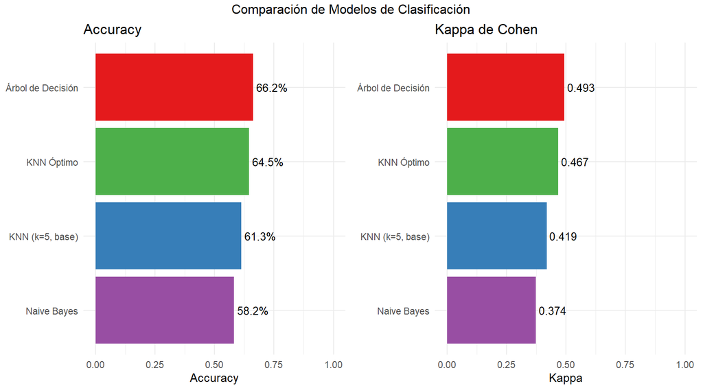

Accuracy comparativo entre modelos de clasificación

```r
tabla_clas_plot <- tabla_clas %>% filter(!is.na(Kappa))

p1 <- ggplot(tabla_clas_plot, aes(x = reorder(Modelo, Accuracy), y = Accuracy, fill = Modelo)) +
  geom_col(show.legend = FALSE) +
  coord_flip() +
  geom_text(aes(label = scales::percent(Accuracy, accuracy = 0.1)), hjust = -0.1, size = 3.5) +
  labs(title = "Accuracy", x = NULL) +
  theme_minimal() +
  scale_fill_brewer(palette = "Set1") +
  ylim(0, 1)

p2 <- ggplot(tabla_clas_plot, aes(x = reorder(Modelo, Kappa), y = Kappa, fill = Modelo)) +
  geom_col(show.legend = FALSE) +
  coord_flip() +
  geom_text(aes(label = round(Kappa, 3)), hjust = -0.1, size = 3.5) +
  labs(title = "Kappa de Cohen", x = NULL) +
  theme_minimal() +
  scale_fill_brewer(palette = "Set1") +
  ylim(0, 1)

gridExtra::grid.arrange(p1, p2, ncol = 2,
                         top = "Comparación de Modelos de Clasificación")
```

### 8.0.1 Matrices de confusión de todos los modelos

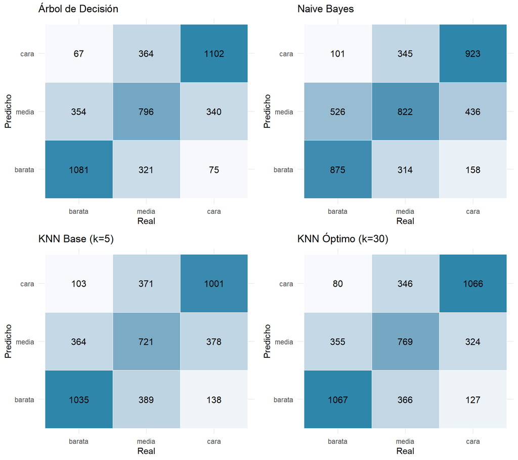

Matrices de confusión comparadas

```r
hacer_mapa <- function(conf, titulo) {
  df <- as.data.frame(conf)
  names(df) <- c("Predicho", "Real", "Freq")
  ggplot(df, aes(x = Real, y = Predicho, fill = Freq)) +
    geom_tile(color = "white") +
    geom_text(aes(label = Freq), size = 4) +
    scale_fill_gradient(low = "#F7F9FC", high = "#2E86AB") +
    labs(title = titulo, x = "Real", y = "Predicho") +
    theme_minimal() +
    theme(legend.position = "none")
}

g1 <- hacer_mapa(conf_arbol, "Árbol de Decisión")
g2 <- hacer_mapa(conf_nb,    "Naive Bayes")
g3 <- hacer_mapa(conf_base_m,"KNN Base (k=5)")
g4 <- hacer_mapa(conf_opt_m, paste0("KNN Óptimo (k=", mejor_clas$k, ")"))

gridExtra::grid.arrange(g1, g2, g3, g4, ncol = 2)
```

# 9 Análisis de Resultados y Conclusiones

## 9.1 Distancia óptima para KNN

```r
cat("=== Análisis de métrica de distancia ===\n\n")
```

```
## === Análisis de métrica de distancia ===
```

```r
cat("Regresión — mejor métrica:\n")
```

```
## Regresión — mejor métrica:
```

```r
cat("  p =", mejor_reg$p,
    ifelse(mejor_reg$p == 1, "(Manhattan)",
    ifelse(mejor_reg$p == 2, "(Euclidiana)", "(Minkowski p=3)")), "\n")
```

```
##   p = 1 (Manhattan)
```

```r
cat("  k =", mejor_reg$k, "\n\n")
```

```
##   k = 10
```

```r
cat("Clasificación — mejor métrica:\n")
```

```
## Clasificación — mejor métrica:
```

```r
cat("  p =", mejor_clas$p,
    ifelse(mejor_clas$p == 1, "(Manhattan)",
    ifelse(mejor_clas$p == 2, "(Euclidiana)", "(Minkowski p=3)")), "\n")
```

```
##   p = 1 (Manhattan)
```

```r
cat("  k =", mejor_clas$k, "\n\n")
```

```
##   k = 30
```

```r
cat("Interpretación:\n")
```

```
## Interpretación:
```

```r
cat("  La distancia Euclidiana (p=2) es generalmente preferida cuando las features\n")
```

```
##   La distancia Euclidiana (p=2) es generalmente preferida cuando las features
```

```r
cat("  están bien normalizadas y no hay outliers extremos, como en este caso.\n")
```

[output not shown]

```r
cat("  Manhattan (p=1) puede ser más robusta cuando hay muchas dimensiones.\n")
```

```
##   Manhattan (p=1) puede ser más robusta cuando hay muchas dimensiones.
```

## 9.2 Resumen ejecutivo final

```r
cat("=== RESUMEN EJECUTIVO ===\n\n")
```

```
## === RESUMEN EJECUTIVO ===
```

```r
cat("REGRESIÓN (predicción de precio):\n")
```

```
## REGRESIÓN (predicción de precio):
```

```r
cat("  Mejor modelo:", tabla_reg$Modelo[which.min(tabla_reg$RMSE)], "\n")
```

```
##   Mejor modelo: KNN CV (10-fold)
```

```r
cat("  RMSE:", min(tabla_reg$RMSE), "USD\n\n")
```

```
##   RMSE: 118.57 USD
```

```r
cat("CLASIFICACIÓN (categoría de precio):\n")
```

```
## CLASIFICACIÓN (categoría de precio):
```

```r
acc_max <- max(tabla_clas$Accuracy, na.rm = TRUE)
cat("  Mejor modelo:", tabla_clas$Modelo[which.max(tabla_clas$Accuracy)], "\n")
```

```
##   Mejor modelo: Árbol de Decisión
```

```r
cat("  Accuracy:", scales::percent(acc_max, accuracy = 0.1), "\n\n")
```

```
##   Accuracy: 66.2%
```

```r
cat("RECOMENDACIÓN PARA SMARTSTAY:\n")
```

```
## RECOMENDACIÓN PARA SMARTSTAY:
```

```r
cat("  Para estimación de precio numérico, el modelo con menor RMSE\n")
```

```
##   Para estimación de precio numérico, el modelo con menor RMSE
```

```r
cat("  ofrece la predicción más precisa.\n")
```

```
##   ofrece la predicción más precisa.
```

```r
cat("  Para clasificación de rango de precio, el modelo con mayor\n")
```

```
##   Para clasificación de rango de precio, el modelo con mayor
```

```r
cat("  accuracy y Kappa es preferible porque también considera el\n")
```

```
##   accuracy y Kappa es preferible porque también considera el
```

```r
cat("  balance entre clases, no solo el error global.\n")
```

```
##   balance entre clases, no solo el error global.
```